# HCA Clustering Using R

Etana Disasa

10/27/2019

# Introduction

##### In this assignment, we will use a small Wholesale Customer dataset to perform Hierarchical Clustering Approach (HCA). Furthermore, we will try to cut the tree to see which clustering best performs the classification process.

# Methods

## Acquiring Data

##### The data we are using is a Wholesale Customer information. It contains several data points. It has 440 observations and 8 variables.

```r
MyData <- read.csv(file = "Wholesale customers data.csv", header = TRUE)
str(MyData)
```

```
## 'data.frame':    440 obs. of  8 variables:
##  $ Channel         : int  2 2 2 1 2 2 2 2 1 2 ...
##  $ Region          : int  3 3 3 3 3 3 3 3 3 3 ...
##  $ Fresh           : int  12669 7057 6353 13265 22615 9413 12126 7579 5963 6006 ...
##  $ Milk            : int  9656 9810 8808 1196 5410 8259 3199 4956 3648 11093 ...
##  $ Grocery         : int  7561 9568 7684 4221 7198 5126 6975 9426 6192 18881 ...
##  $ Frozen          : int  214 1762 2405 6404 3915 666 480 1669 425 1159 ...
##  $ Detergents_Paper: int  2674 3293 3516 507 1777 1795 3140 3321 1716 7425 ...
##  $ Delicassen      : int  1338 1776 7844 1788 5185 1451 545 2566 750 2098 ...
```

```r
MyData <- na.omit(MyData) # Making sure there is not a data row with NA (no) data in it.
MyData <- scale(MyData) # Scaling the dataset is very important as we are dealing with k means to cluster
head(MyData, n=10)
```

```
##       Channel    Region        Fresh        Milk     Grocery     Frozen
## 1   1.4470045 0.5899967  0.052873004  0.52297247 -0.04106815 -0.5886970
## 2   1.4470045 0.5899967 -0.390857056  0.54383861  0.17012470 -0.2698290
## 3   1.4470045 0.5899967 -0.446520984  0.40807319 -0.02812509 -0.1373793
## 4  -0.6895122 0.5899967  0.099997579 -0.62331041 -0.39253008  0.6863630
## 5   1.4470045 0.5899967  0.839284120 -0.05233688 -0.07926595  0.1736612
## 6   1.4470045 0.5899967 -0.204572662  0.33368675 -0.29729863 -0.4955909
## 7   1.4470045 0.5899967  0.009939037 -0.35191506 -0.10273183 -0.5339045
## 8   1.4470045 0.5899967 -0.349583519 -0.11385135  0.15518231 -0.2889858
## 9  -0.6895122 0.5899967 -0.477357535 -0.29107807 -0.18512545 -0.5452338
## 10  1.4470045 0.5899967 -0.473957607  0.71767797  1.15011422 -0.3940392
##    Detergents_Paper  Delicassen
## 1       -0.04351919 -0.06626363
## 2        0.08630859  0.08904969
## 3        0.13308016  2.24074190
## 4       -0.49802132  0.09330484
## 5       -0.23165413  1.29786952
## 6       -0.22787885 -0.02619421
## 7        0.05421869 -0.34745874
## 8        0.09218126  0.36918101
## 9       -0.24444815 -0.27476643
## 10       0.95294579  0.20322979
```

## HCA Clustering

##### The hierarchical clustering algorithm I am using `hclust` uses the `complete` linkage method which is the default linkage method. I will also use `average` and `single` linkage methods to compare the results later.

```r
hcCluster <- hclust(dist(MyData, method = "euclidean"), method="complete")
hcCluster1 <- hclust(dist(MyData, method = "euclidean"), method="average")
hcCluster2 <- hclust(dist(MyData, method = "euclidean"), method="single")
hcCluster3 <- hclust(dist(MyData, method = "euclidean"), method = "ward.D")
```

## Identifying Optimal Clusters Using the Silhouette Plot

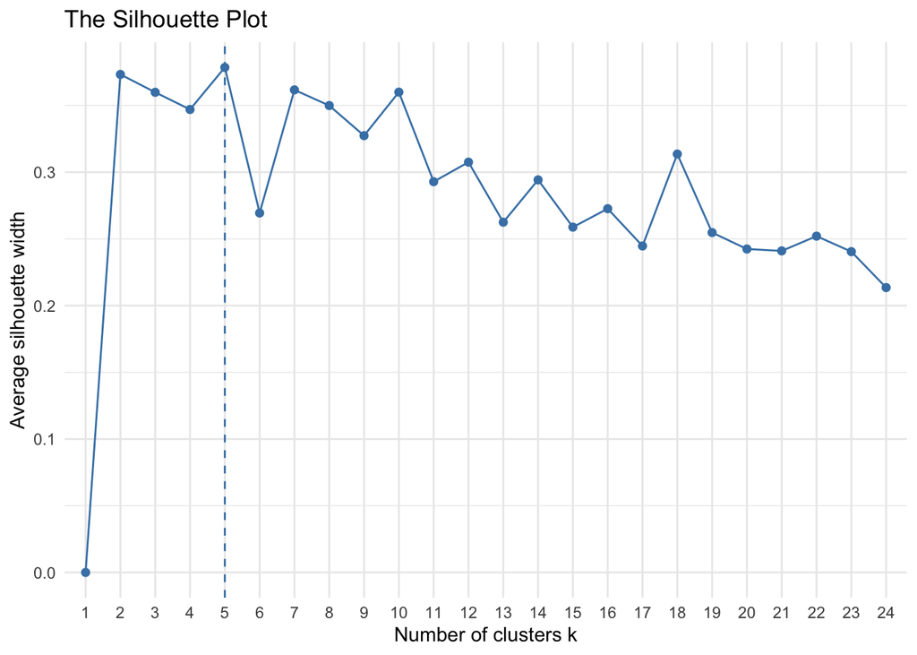

```r
fviz_nbclust(MyData, kmeans, method = "silhouette", k.max = 24) + theme_minimal() + ggtitle("The Silhouette Plot")
```

## Plotting Dendrogram of Various Linkages

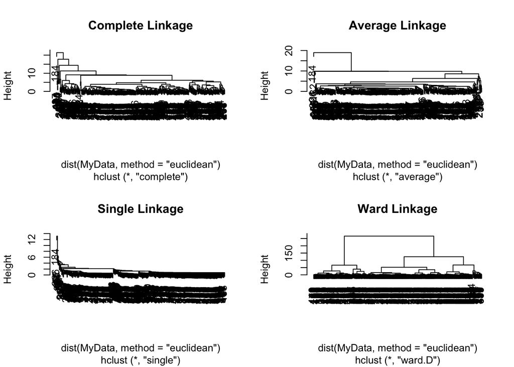

```r
par(mfrow=c(2,2))
plot(hcCluster, main = "Complete Linkage")
plot(hcCluster1, main = "Average Linkage")
plot(hcCluster2, main = "Single Linkage")
plot(hcCluster3, main = "Ward Linkage")
```

### Cutting Dendrogram

##### Given I have identified an optimal cluster number 5, I will use that to cut the tree. I am using `hcCluster3` for this portion and on. I have used the ward cluster because it appears a balanced tree compared to the others.

```r
hcCutK <- cutree(hcCluster3, k = 5)
table(hcCutK)
```

```
## hcCutK
##   1   2   3   4   5
## 101 201  24  40  74
```

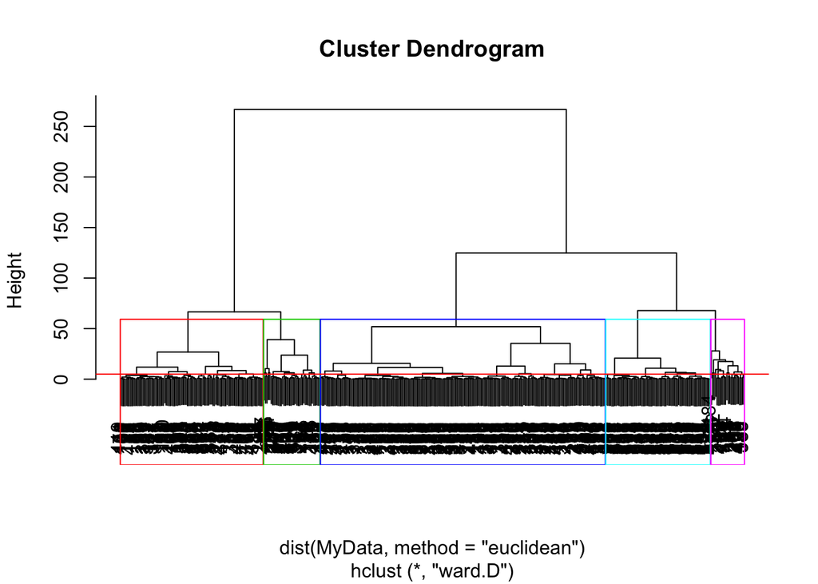

```r
plot(hcCluster3)
rect.hclust(hcCluster3 , k = 5, border = 2:7)
abline(h = 5, col = 'red')
```

##### The above plot shows 5 clusters diffrentiated in five different colors.

```r
hcCut <- cutree(hcCluster3, 7)
table(hcCut)
```

```
## hcCut
##   1   2   3   4   5   6   7
## 101  87 114  24  35   5  74
```

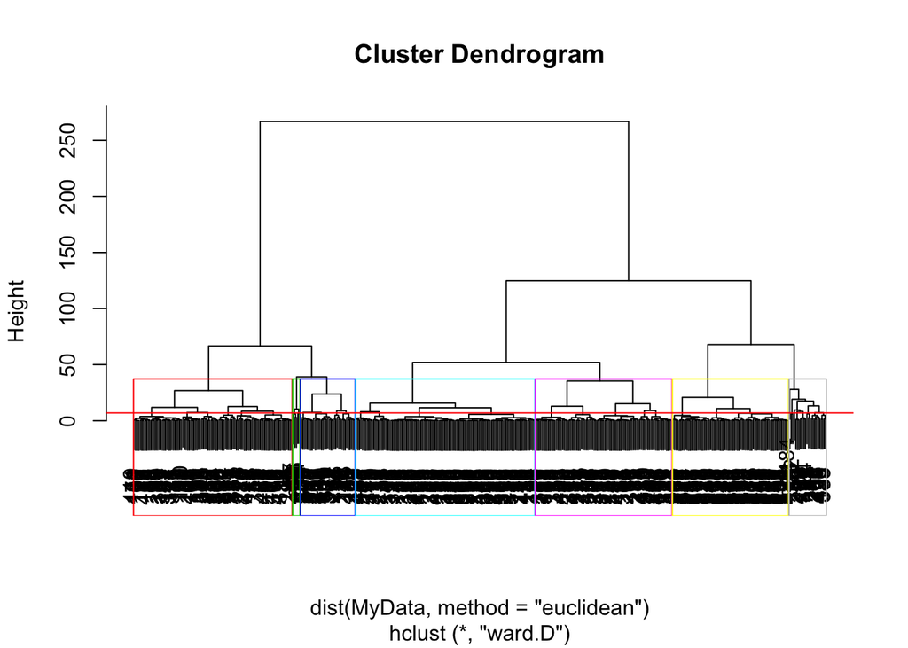

```r
plot(hcCluster3)
rect.hclust(hcCluster3 , k = 7, border = 2:9)
abline(h = 7, col = 'red')
```

##### Here, the above k value of 7 cuts the three in 7 seven clusters. Below is another cool display of the dendrogram with the spectrum of colors.

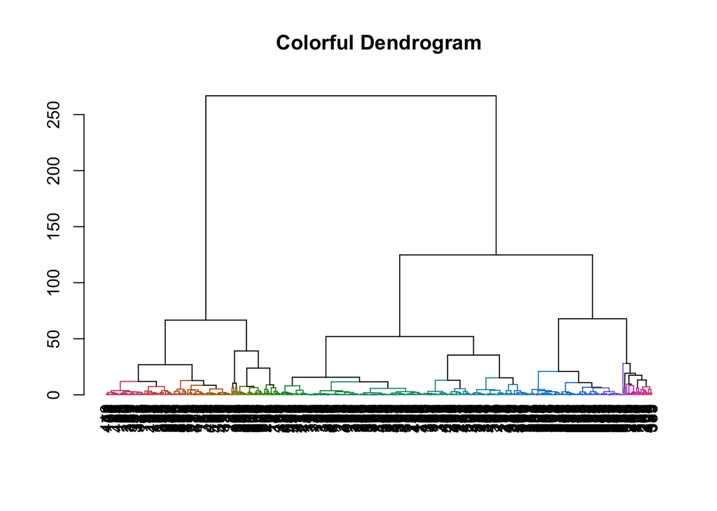

```r
dend_obj <- as.dendrogram(hcCluster3)
col_dend <- color_branches(dend_obj, h = 5)
plot(col_dend, main = "Colorful Dendrogram")
```

# Conclusion

##### Cutting the tree on the dendrogram is an observational process. The various linkages determine the kind of tree we will get. Once again, making sure the data has no NA values, that it is numeric, and that is scaled are very important in performing clustering.

# References

http://www.sthda.com/english/wiki/print.php?id=237  
http://www.sthda.com/english/wiki/print.php?id=237  
https://afit-r.github.io/hc_clustering  
https://rpubs.com/AIventurer/unsupervised_learning_ch2